# Investment Behavior in Turkey

Suphi Pasa - IE360 - Fall 2020

# Investment Behavior

First install the packages then read the data and create a data.frame and data.table

[output not shown]

[output not shown]

[output not shown]

[output not shown]

[output not shown]

[output not shown]

[output not shown]

```r
df <- read.xlsx("C:\\Users\\olum_\\Desktop\\data.xlsx", sheet = 1,
                startRow = 1,
                colNames = TRUE,
                rowNames = FALSE,
                detectDates = TRUE,
                cols = NULL,
                check.names = FALSE,

)


dt <- data.table(df)
setnames(dt, c("tarih","konut","altin_fiyat", "kur"))
dt[, tarih := as.Date(paste(tarih, "01", sep = "-")),]
```

## Graphs

First look at the graphs of the top three investment choices for Turkish People; Gold, Euro and Real Estate.

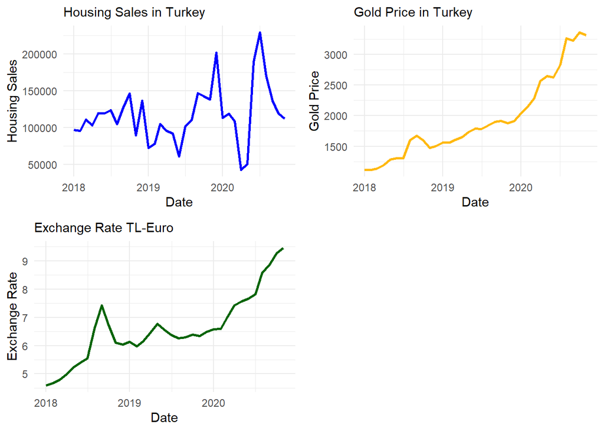

Foreign currency, gold and real estate have always been investment options for us. We can see from the graphs that Euro and Gold is always a good choice for invest, they are mostly increasing. Housing on the other hand generally increasing but riskier than other two. Steady increase in gold and Euro can explained by constant value loss in TL but apparently house sales moves unexpectedly. I expected all to be increasing together.

## Histograms

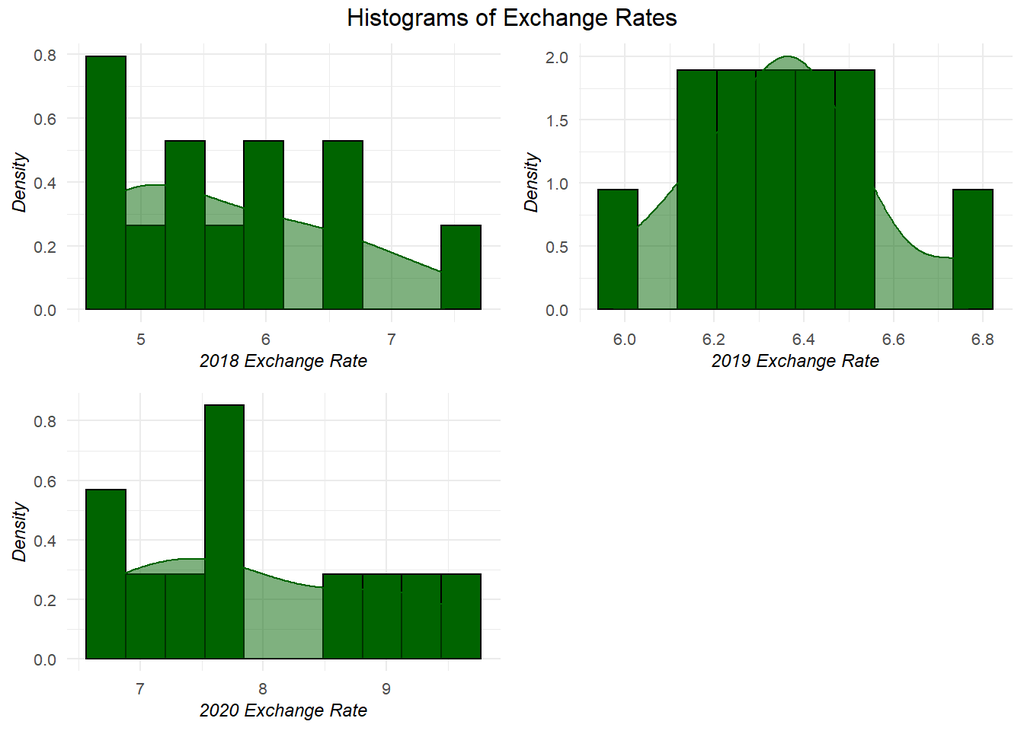

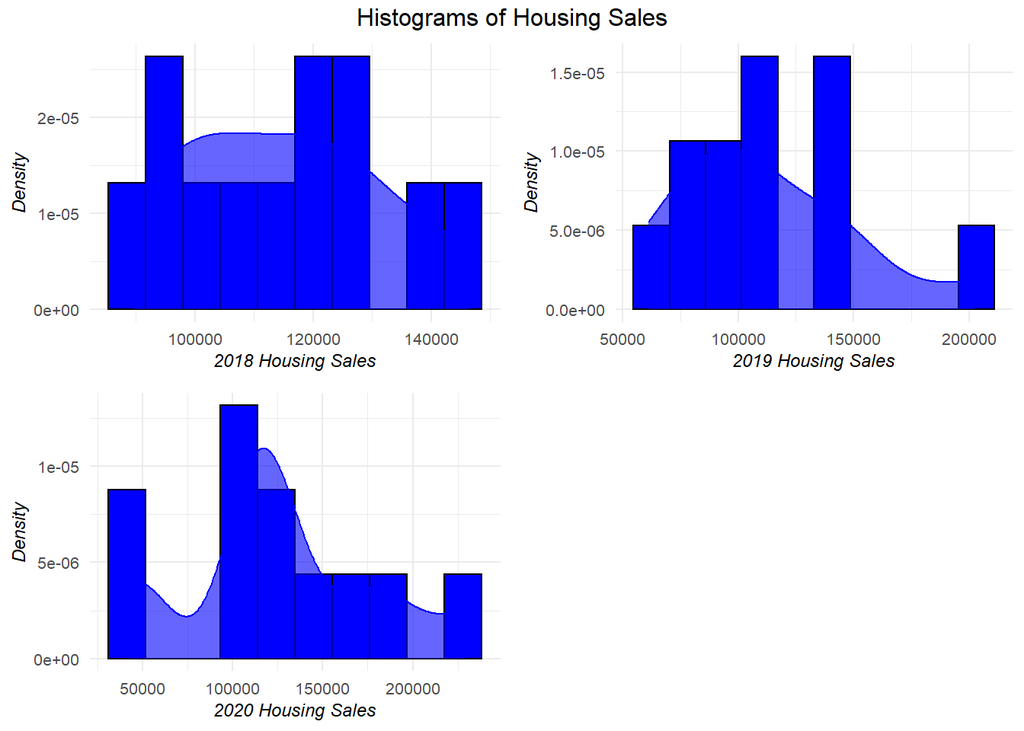

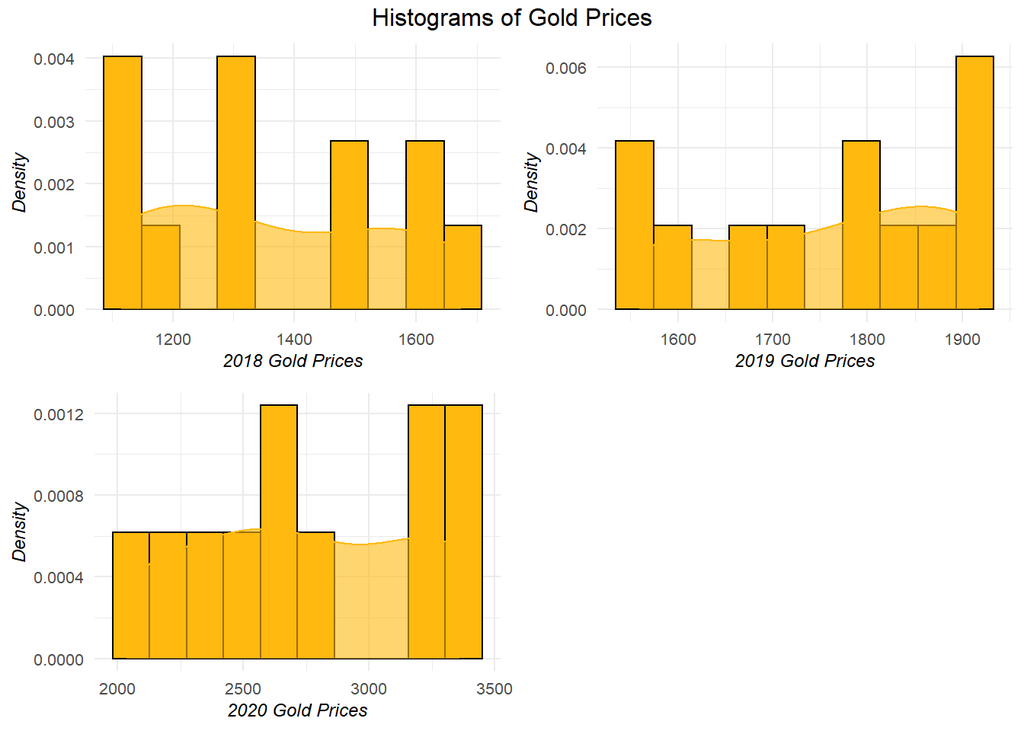

Again we can see the increase and like exchange rate these histograms are stable too.

## Correlation

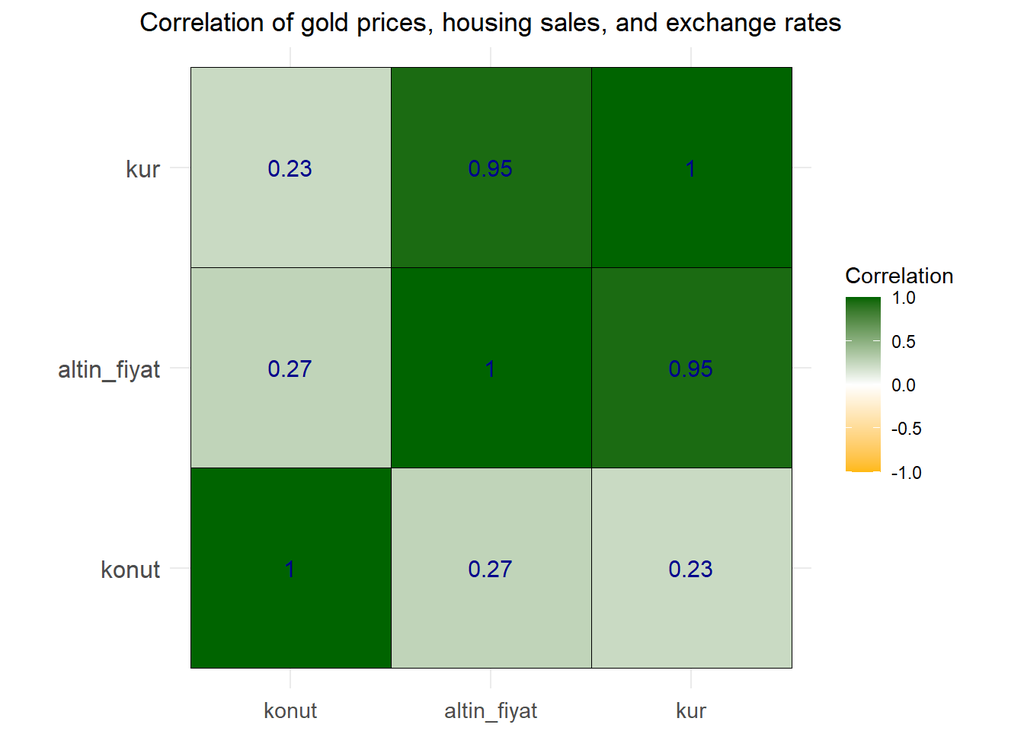

As we anticipated gold prices and exchange rates are highly correlated, the decreasing value of TL can explain it clearly, but estate sales and others and hardly correlated and I think the reason is people choose high liquid investments over estate in crisis times.

## Codes Used

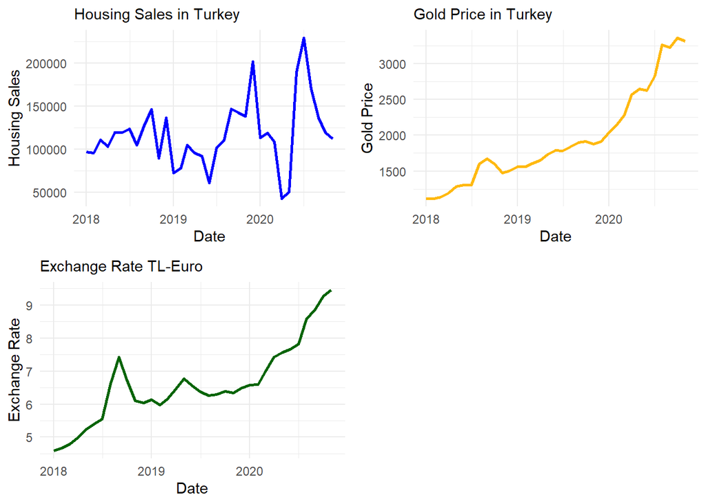

```r
 p1 <- ggplot(dt, aes(x=tarih, y=konut, group = 1)) +
  geom_line(size = 1, colour = "blue") +
  labs(title = "Housing Sales in Turkey",
       x = "Date",
       y = "Housing Sales") +
  theme_minimal() +
  theme(plot.title = element_text(size=11))

p2 <- ggplot(dt, aes(x=tarih, y=altin_fiyat)) + geom_line(size = 1, colour = "darkgoldenrod1") +
  labs(title = "Gold Price in Turkey",
       x = "Date",
       y = "Gold Price") +
  theme_minimal() +
  theme(plot.title = element_text(size=11))


p3 <- ggplot(dt, aes(x=tarih, y=kur, group = 1)) + geom_line(size = 1, colour = "darkgreen") +
  labs(title = "Exchange Rate TL-Euro",
       x = "Date",
       y = "Exchange Rate") +
  theme_minimal() +
  theme(plot.title = element_text(size=11))


grid.arrange(p1,p2,p3, ncol=2)
```

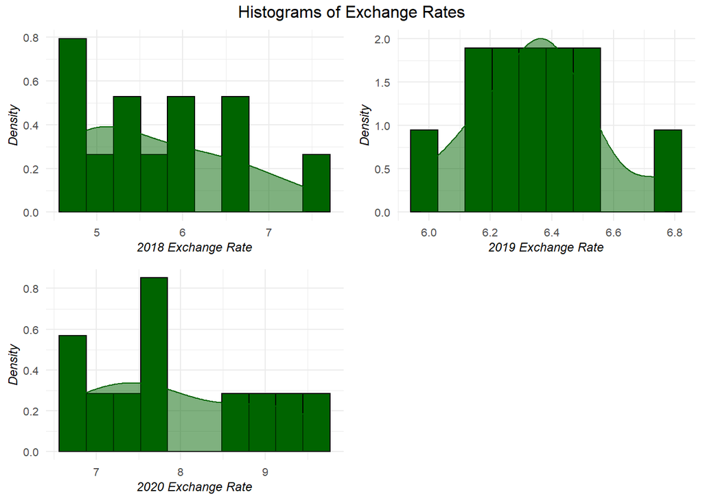

```r
#Visual representation of the data as histograms

plot_list <- vector(mode = "list", length = 3)
j=1
for(i in 2018:2020){
  start <- as.Date(paste(i, "01-01", sep = "-"))

  end <- as.Date(paste(i, "12-31", sep = "-"))

  x <- dt[tarih>=start & tarih<=end]

  p <- ggplot(x, aes(x= kur)) +
    geom_histogram( aes(y=..density..),colour = "black", alpha=1, fill = "darkgreen", bins= 10) +
    geom_density(alpha=0.5, colour = "darkgreen", fill = "darkgreen") +
    labs(x= paste(i, "Exchange Rate", sep = " "),
         y="Density") +
    theme_minimal() +
    theme(axis.text=element_text(size=8), axis.title=element_text(size=9,face="italic"))

  plot_list[[j]] <- p
  j <- j+1
}
do.call('grid.arrange',c(plot_list, ncol = 2, top="Histograms of Exchange Rates"))
```

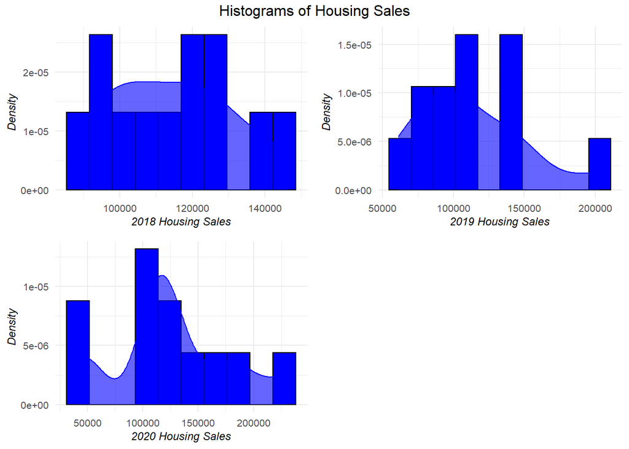

```r
plot_list2 <- vector(mode = "list", length = 3)
j=1
for(i in 2018:2020){
  start <- as.Date(paste(i, "01-01", sep = "-"))

  end <- as.Date(paste(i, "12-31", sep = "-"))

  x <- dt[tarih>=start & tarih<=end]

  p <- ggplot(x, aes(x=konut)) +
    geom_histogram( aes(y=..density..),colour = "black", alpha=1, fill = "blue", bins= 10) +
    geom_density(alpha=0.6, colour = "blue", fill = "blue") +
    labs(x= paste(i, "Housing Sales", sep = " "),
         y="Density") +
    theme_minimal() +
    theme(axis.text=element_text(size=8), axis.title=element_text(size=9,face="italic"))

  plot_list2[[j]] <- p
  j <- j+1
}
do.call('grid.arrange',c(plot_list2, ncol = 2, top="Histograms of Housing Sales"))
```

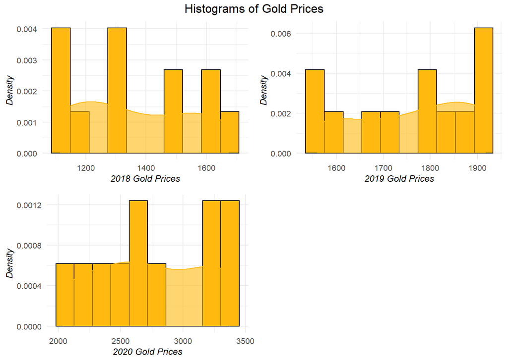

```r
plot_list3 <- vector(mode = "list", length = 3)
j=1
for(i in 2018:2020){
  start <- as.Date(paste(i, "01-01", sep = "-"))

  end <- as.Date(paste(i, "12-31", sep = "-"))

  x <- dt[tarih>=start & tarih<=end]

  p <- ggplot(x, aes(x=altin_fiyat)) +
    geom_histogram( aes(y=..density..),colour = "black", alpha=1, fill = "darkgoldenrod1", bins= 10) +
    geom_density(alpha=0.6, colour = "darkgoldenrod1", fill = "darkgoldenrod1") +
    labs(x= paste(i, "Gold Prices", sep = " "),
         y="Density") +
    theme_minimal() +
    theme(axis.text=element_text(size=8), axis.title=element_text(size=9,face="italic"))

  plot_list3[[j]] <- p
  j <- j+1
}
do.call('grid.arrange',c(plot_list3, ncol = 2, top="Histograms of Gold Prices"))
```

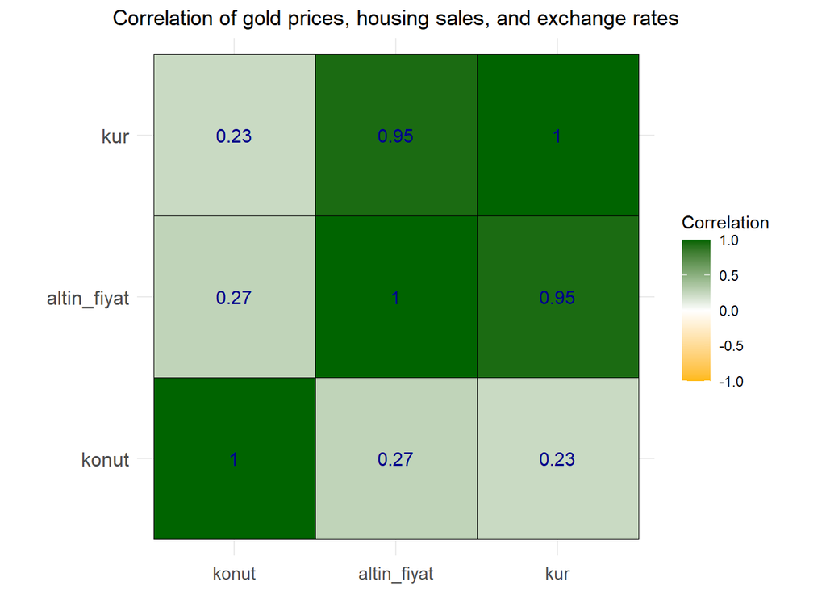

```r
# Correlation
cm <- cor(dt[,-c(1)])

cp <- ggcorrplot(cm, method = "square", lab_col = "darkblue",
                                    show.legend = TRUE, lab = TRUE, outline.col = "black",
                                    title = "Correlation of gold prices, housing sales, and exchange rates", colors = c("darkgoldenrod1","white","darkgreen"),
                                    legend.title = "Correlation") + theme(plot.title=element_text(hjust=0.5),
                                                                          axis.text.x = element_text(angle = 0, size=11, vjust =0.5, hjust=0.5))

grid.arrange(cp, ncol=1)
```